# Notebook

## Data Pre Processing

### Disciplined Workflow

Since data manipulation is easier in pandas, and there are multiple iterative steps ahead, we shall stick to a discipline. Data Pre Processing and Data Standardization are two main stages of data manipulation. After that, we only tune classifiers and evaluate. So for these first two stages, after we load raw `data_dict`, we shall convert to pandas data frame, and perform operations related to these stages and then before Classifier tuning, we convert it back to `my_dataset` as needed by our starter code.

```python
from graphviz import Digraph
g = Digraph('Work Flow',  node_attr={'shape': 'record'})
g.attr(rankdir='LR')

g.node('step_0', r'Dict To Df', style='filled', fillcolor='#BBDEFB')
g.node('step_1', r'1. Data\nPreProcessing',style='filled', fillcolor='#e6a26a')
g.node('step_2', r'2. Data\nStandardization', style='filled', fillcolor='#e6a26a')
g.node('step_2_5', r'Df to Dict', style='filled', fillcolor='#BBDEFB')

g.node('step_3', r'3. Classifier\nTuning', style='filled', fillcolor='#e6a26a')
g.node('step_4', r'4. Evaluation\nMetrics', style='filled', fillcolor='#e6a26a')

g.edges([('step_0','step_1'),('step_1','step_2'),('step_2','step_2_5'),('step_2_5','step_3'),('step_3','step_4')])
g
```

[figure not shown]

Jumping into our current code setup, we thus would have something like this to start up. Please recall functions from earlier section, now they are just pushed to library for brevity. When we define new functions,we also will add them to library when we try to reuse next time. Also note, we have switched to Decision tree classifier as decided earlier.

```python
from helpers_2 import init, split_data, tree_classify, evaluate
import pandas as pd

# raw data
data_dict = init()

# Dict to Df
df = pd.DataFrame.from_dict(data_dict, orient='index')  # 'index' means keys should be rows

#-------------- PANDAS AREA --------------------
# 1. PRE PROCESSING
# 1.1. Cleaning Invalid Values ('NaN')
# 1.2. Remove Outliers

# 2. STANDARDIZATION
# 2.1. Feature Scaling
# 2.2. Feature Selection
features_list = ['poi','salary']
#-------------- PANDAS AREA --------------------

# Df to Dict
data_dict = df.to_dict('index') # 'index' means convert to dict like {index -> {column -> value}}

# CLASSIFIER
my_dataset = data_dict  # just for udacity's convention
labels, features = split_data(my_dataset, features_list)
clf = tree_classify(random_state=0)  # random state 0 to maintain consistent results everytime its run

# EVALUATION
trained_clf = evaluate(clf, my_dataset, features_list)
```

```
Udacity's Evaluation:
DecisionTreeClassifier(class_weight=None, criterion='gini', max_depth=None,
            max_features=None, max_leaf_nodes=None,
            min_impurity_decrease=0.0, min_impurity_split=None,
            min_samples_leaf=1, min_samples_split=2,
            min_weight_fraction_leaf=0.0, presort=False, random_state=0,
            splitter='best')

Accuracy: 0.69210	Precision: 0.23619	Recall: 0.24150	F1: 0.23881	F2: 0.24042
Total predictions: 10000
True positives:  483	False positives: 1562	False negatives: 1517	True negatives: 6438
```

## 1.1 Cleaning Invalid Values

Let us have a sneak peak in to our raw data

```python
df.head()
```

|  | salary | to_messages | deferral_payments | total_payments | exercised_stock_options | bonus | restricted_stock | shared_receipt_with_poi | restricted_stock_deferred | total_stock_value | ... | loan_advances | from_messages | other | from_this_person_to_poi | poi | director_fees | deferred_income | long_term_incentive | email_address | from_poi_to_this_person |
| --- | --- | --- | --- | --- | --- | --- | --- | --- | --- | --- | --- | --- | --- | --- | --- | --- | --- | --- | --- | --- | --- |
| ALLEN PHILLIP K | 201955 | 2902 | 2869717 | 4484442 | 1729541 | 4175000 | 126027 | 1407 | -126027 | 1729541 | ... | NaN | 2195 | 152 | 65 | False | NaN | -3081055 | 304805 | phillip.allen@enron.com | 47 |
| BADUM JAMES P | NaN | NaN | 178980 | 182466 | 257817 | NaN | NaN | NaN | NaN | 257817 | ... | NaN | NaN | NaN | NaN | False | NaN | NaN | NaN | NaN | NaN |
| BANNANTINE JAMES M | 477 | 566 | NaN | 916197 | 4046157 | NaN | 1757552 | 465 | -560222 | 5243487 | ... | NaN | 29 | 864523 | 0 | False | NaN | -5104 | NaN | james.bannantine@enron.com | 39 |
| BAXTER JOHN C | 267102 | NaN | 1295738 | 5634343 | 6680544 | 1200000 | 3942714 | NaN | NaN | 10623258 | ... | NaN | NaN | 2660303 | NaN | False | NaN | -1386055 | 1586055 | NaN | NaN |
| BAY FRANKLIN R | 239671 | NaN | 260455 | 827696 | NaN | 400000 | 145796 | NaN | -82782 | 63014 | ... | NaN | NaN | 69 | NaN | False | NaN | -201641 | NaN | frank.bay@enron.com | NaN |

5 rows ' 21 columns

Note the invalid values are marked with **'NaN'**. Note that out of all features, except `email_address` and `poi` others are numerical. For these numerical values, we learn, 'NaN' means not, not available but 0. Before trying to spot outliers, we need to clean such invalid entries

```python
def clean_df(raw_df):
    """
    Replace 'NaN' with 0 in all feature columns, except 'poi' and 'email_address'
    Return updated df
    """
    # replace NaN except poi and email_address (ref: https://stackoverflow.com/questions/42916989/replace-missing-values-in-all-columns-except-one-in-pandas-dataframe)
    data_panda_1 = raw_df.loc[:, raw_df.columns.difference(['poi','email_address'])].replace('NaN',0, regex=True)
    # caz we have to now concat caz of these cols lost in above df
    data_panda_2 = raw_df[['poi','email_address']]
    # concat (remember axis 1)
    data_panda = pd.concat([data_panda_1, data_panda_2],axis=1, sort=False)
    # fix exponential display formatdue to replace operaiton (ref: https://stackoverflow.com/questions/42735541/customized-float-formatting-in-a-pandas-dataframe)
    pd.options.display.float_format = lambda x : '{:.0f}'.format(x) # we dont both about decimal accuracies here for calculated means, stds etc.
    return data_panda

test_df = clean_df(df)
test_df.head()
```

|  | bonus | deferral_payments | deferred_income | director_fees | exercised_stock_options | expenses | from_messages | from_poi_to_this_person | from_this_person_to_poi | loan_advances | ... | other | restricted_stock | restricted_stock_deferred | salary | shared_receipt_with_poi | to_messages | total_payments | total_stock_value | poi | email_address |
| --- | --- | --- | --- | --- | --- | --- | --- | --- | --- | --- | --- | --- | --- | --- | --- | --- | --- | --- | --- | --- | --- |
| ALLEN PHILLIP K | 4175000 | 2869717 | -3081055 | 0 | 1729541 | 13868 | 2195 | 47 | 65 | 0 | ... | 152 | 126027 | -126027 | 201955 | 1407 | 2902 | 4484442 | 1729541 | False | phillip.allen@enron.com |
| BADUM JAMES P | 0 | 178980 | 0 | 0 | 257817 | 3486 | 0 | 0 | 0 | 0 | ... | 0 | 0 | 0 | 0 | 0 | 0 | 182466 | 257817 | False | NaN |
| BANNANTINE JAMES M | 0 | 0 | -5104 | 0 | 4046157 | 56301 | 29 | 39 | 0 | 0 | ... | 864523 | 1757552 | -560222 | 477 | 465 | 566 | 916197 | 5243487 | False | james.bannantine@enron.com |
| BAXTER JOHN C | 1200000 | 1295738 | -1386055 | 0 | 6680544 | 11200 | 0 | 0 | 0 | 0 | ... | 2660303 | 3942714 | 0 | 267102 | 0 | 0 | 5634343 | 10623258 | False | NaN |
| BAY FRANKLIN R | 400000 | 260455 | -201641 | 0 | 0 | 129142 | 0 | 0 | 0 | 0 | ... | 69 | 145796 | -82782 | 239671 | 0 | 0 | 827696 | 63014 | False | frank.bay@enron.com |

5 rows ' 21 columns

Now, let us include in our main workflow and check scores..

```python
from helpers_2 import init, split_data, tree_classify, evaluate
from helpers_2 import clean_df
import pandas as pd

# raw data
data_dict = init()

# Dict to Df
df = pd.DataFrame.from_dict(data_dict, orient='index')  # 'index' means keys should be rows

#-------------- PANDAS AREA --------------------
# 1. PRE PROCESSING
# 1.1. Cleaning Invalid Values ('NaN')
df = clean_df(df)
# 1.2. Remove Outliers

# 2. STANDARDIZATION
# 2.1. Feature Scaling
# 2.2. Feature Selection
features_list = ['poi','salary']
#-------------- PANDAS AREA --------------------

# Df to Dict
data_dict = df.to_dict('index') # 'index' means convert to dict like {index -> {column -> value}}

# CLASSIFIER
my_dataset = data_dict  # just for udacity's convention
labels, features = split_data(my_dataset, features_list)
clf = tree_classify(random_state=0)  # random state 0 to maintain consistent results everytime its run

# EVALUATION
trained_clf = evaluate(clf, my_dataset, features_list)
```

```
Udacity's Evaluation:
DecisionTreeClassifier(class_weight=None, criterion='gini', max_depth=None,
            max_features=None, max_leaf_nodes=None,
            min_impurity_decrease=0.0, min_impurity_split=None,
            min_samples_leaf=1, min_samples_split=2,
            min_weight_fraction_leaf=0.0, presort=False, random_state=0,
            splitter='best')

Accuracy: 0.69210	Precision: 0.23619	Recall: 0.24150	F1: 0.23881	F2: 0.24042
Total predictions: 10000
True positives:  483	False positives: 1562	False negatives: 1517	True negatives: 6438
```

No difference, this only means sklearn simply took 'NaN's as 0, or ignored. Nevertheless, our df is now cleaner for spotting outliers.

## 1.2 Remove Outliers

Outliers could be of many types. For numerical features, some of them could be

1. Those that max out too farther away in either positive or negative direction (can spot in graph)
2. Those that are out of place (for eg, should be always positive, but outlier is negative)

The 1st type is easy to detect usually by visualizing. However, some may require more than 1 iteration. That is, an outlier may become visibly obvious, only after removing another which was much farther.

The 2nd type is usually harder to detect, as that needs knowledge about the features. For eg, we have `total_stock_value`, which is supposed to be always positive because its the sum of stock prices which themselves cannot be negative, so a value negative under this could be an outlier. If too negative, it might show up in visuals, but if not, might be difficult to spot.

Outliers thus, by nature, may typically require iterative investigation and feature knowledge apart from just visualization. Also we shall remove only if outlier is not POI

### Outlier Iteration 1

Let us start spotting by visualizing. For brevity, the visualizing functions are abstracted. The outliers are annotated as well (I had to code upfront who are they to annotate)

`We try to spot the outliers of type 1 - maxing out in positive direction`

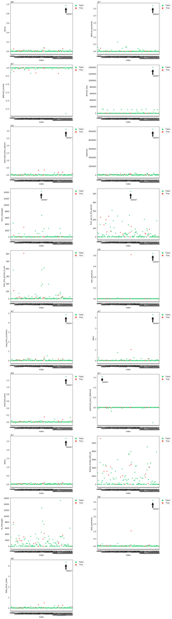

```python
from helpers_2 import stripplots, get_feature_max

# test df for our analysis
test_df = df

# outliers in this iteration (can create this list after once visualizing without this annotation and choose features from graphs)
outlier_feature_list = [
    'bonus', 'deferral_payments', 'director_fees','exercised_stock_options',
    'expenses','from_messages', 'from_poi_to_this_person', 'loan_advances',
    'long_term_incentive','other','restricted_stock','restricted_stock_deferred',
    'salary','total_payments','total_stock_value'
    ]
outlier_dict = get_feature_max(test_df, outlier_feature_list)

# plot
stripplots(test_df, outlier_dict)
```

Let us find out who are those outliers, and remove them first.

```python
from helpers_2 import get_index_label

outlier_list = []
for k,v in outlier_dict.iteritems():
    outlier = get_index_label(test_df, k, v)
    outlier_list.append(outlier)

outlier_list = list(set(outlier_list)) # to remove duplicates
outlier_list
```

```
['LAVORATO JOHN J', 'TOTAL', 'KAMINSKI WINCENTY J', 'BHATNAGAR SANJAY']
```

`TOTAL` obviously seems to be an entry error, that the TOTAL values of features from source, are also taken as a valid data point by mistake. Others are not POIs anyway, so we go ahead removing them all.

```python
test_df = test_df.drop(outlier_list)
```

### Outlier Iteration 2

Now that we have removed some of the outliers, let us visualize again with updated data frame. This time, we also inspect negative max outlier.

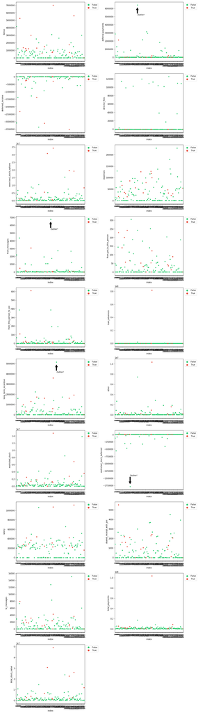

```python
from helpers_2 import get_feature_min

# outliers in this iteration (can create this list after once visualizing without this annotation and choose features from graphs)
outlier_feature_list = ['deferral_payments', 'from_messages', 'long_term_incentive' ]
outlier_dict = get_feature_max(test_df, outlier_feature_list)
outlier_dict_min = get_feature_min(test_df, ['restricted_stock_deferred'])  # negative max as seen on graph
outlier_dict.update(outlier_dict_min)

# plot
stripplots(test_df, outlier_dict)
```

```python
outlier_list = []
for k,v in outlier_dict.iteritems():
    outlier = get_index_label(test_df, k, v)
    outlier_list.append(outlier)

#outlier_list = list(set(outlier_list)) # to remove duplicates
outlier_list
```

```
['KEAN STEVEN J', 'DERRICK JR. JAMES V', 'FREVERT MARK A', 'MARTIN AMANDA K']
```

```python
test_df = test_df.drop(outlier_list)
```

### Outlier Iteration 3

We have almost got rid of type 1 outliers. Type 2 was difficult ( I found this only because of referencing how others did it online ). To spot type 2, let us use pandas description feature, instead of visuals.

```python
description = test_df.describe().loc[['min','max','75%','mean']]
print description
```

```
       bonus  deferral_payments  deferred_income  director_fees  \
min        0            -102500         -3504386              0
max  7000000            3131860                0         125034
75%   797188               5971                0              0
mean  616983             184554          -168401           9415

      exercised_stock_options  expenses  from_messages  \
min                         0         0              0
max                  34348384    228763           4343
75%                   1624050     52905             47
mean                  1941625     34584            199

      from_poi_to_this_person  from_this_person_to_poi  loan_advances  \
min                         0                        0              0
max                       305                      609       81525000
75%                        39                       12              0
mean                       33                       18         593659

      long_term_incentive    other  restricted_stock  \
min                     0        0                 0
max               3600000 10359729          14761694
75%                361719   149831            661377
mean               279831   234830            843709

      restricted_stock_deferred  salary  shared_receipt_with_poi  to_messages  \
min                     -560222       0                        0            0
max                       44093 1111258                     5521        15149
75%                           0  263257                      862         1326
mean                     -22440  172338                      635         1060

      total_payments  total_stock_value
min                0             -44093
max        103559793           49110078
75%          1835865            2180983
mean         1959256            2762231
```

Most of the max values found above, even if found too much compared to 75% could still be ignored, because we alreadyd visually analyzed that they are POIs, so nothing much of non-POIs standing out.

Let us check if `total_payments` and `total_stock_value` are properly calculated. They are sum of individual related feature columns as shown below.

[figure not shown]

### Checking total payments

```python
total_payments_components = ['salary', 'bonus', 'long_term_incentive', 'deferred_income', 'deferral_payments','loan_advances','other','expenses','director_fees']

# calculate sum of individual components and store in 'total_payments_check'
total_df = test_df[total_payments_components]
total_df = total_df.assign(total_check=test_df[total_payments_components].sum(axis=1)) # thanks: https://stackoverflow.com/questions/33750326/compute-row-average-in-pandas

# compare
import numpy as np
total_df['result'] = np.where( (test_df['total_payments'] == total_df['total_check']) ,'correct','wrong')

total_df['result'].value_counts()
```

```
correct    137
wrong        1
Name: result, dtype: int64
```

```python
print get_index_label(total_df,'result','wrong')
```

```
BELFER ROBERT
```

### Checking total stocks

```python
total_stock_components = ['exercised_stock_options','restricted_stock','restricted_stock_deferred']

# calculate sum of individual components and store in 'total_payments_check'
total_df = test_df[total_payments_components]
total_df = total_df.assign(total_check=test_df[total_stock_components].sum(axis=1)) # thanks: https://stackoverflow.com/questions/33750326/compute-row-average-in-pandas

# compare
import numpy as np
total_df['result'] = np.where( (test_df['total_stock_value'] == total_df['total_check']) ,'correct','wrong')

total_df['result'].value_counts()
```

```
correct    137
wrong        1
Name: result, dtype: int64
```

```python
print get_index_label(total_df,'result','wrong')
```

```
BELFER ROBERT
```

So we have a type 2 outlier here. Let us check if he is a POI.

```python
def is_POI(input_df, index_label):
    """
    Given a data frame and index label this function returns if given index label is POI (true) or not
    """
    return input_df.loc[index_label,'poi']

is_POI(test_df, 'BELFER ROBERT')
```

```
False
```

He is not a POI. Thus we could remove him as well.

```python
outlier_list = ['BELFER ROBERT']
test_df = test_df.drop(outlier_list)
```

### Outlier Summary

Through 3 iterations (2 visual, 1 computative), we have found few outliers which we shall remove and check our scores.

```python
def remove_outliers(input_df, outlier_list):
    return input_df.drop(outlier_list)
```

```python
from helpers_2 import init, split_data, tree_classify, evaluate
from helpers_2 import clean_df
import pandas as pd

# raw data
data_dict = init()

# Dict to Df
df = pd.DataFrame.from_dict(data_dict, orient='index')  # 'index' means keys should be rows

#-------------- PANDAS AREA --------------------
# 1. PRE PROCESSING
# 1.1. Cleaning Invalid Values ('NaN')
df = clean_df(df)
# 1.2. Remove Outliers
outlier_list = ['LAVORATO JOHN J', 'TOTAL', 'KAMINSKI WINCENTY J', 'BHATNAGAR SANJAY']  # iteration 1
outlier_list += ['KEAN STEVEN J', 'DERRICK JR. JAMES V', 'FREVERT MARK A', 'MARTIN AMANDA K'] # iteration 2
outlier_list += ['BELFER ROBERT'] # iteration 3
df = remove_outliers(df, outlier_list)

# 2. STANDARDIZATION
# 2.1. Feature Scaling
# 2.2. Feature Selection
features_list = ['poi','salary']
#-------------- PANDAS AREA --------------------

# Df to Dict
data_dict = df.to_dict('index') # 'index' means convert to dict like {index -> {column -> value}}

# CLASSIFIER
my_dataset = data_dict  # just for udacity's convention
labels, features = split_data(my_dataset, features_list)
clf = tree_classify(random_state=0)  # random state 0 to maintain consistent results everytime its run

# EVALUATION
trained_clf = evaluate(clf, my_dataset, features_list)
```

```
Udacity's Evaluation:
DecisionTreeClassifier(class_weight=None, criterion='gini', max_depth=None,
            max_features=None, max_leaf_nodes=None,
            min_impurity_decrease=0.0, min_impurity_split=None,
            min_samples_leaf=1, min_samples_split=2,
            min_weight_fraction_leaf=0.0, presort=False, random_state=0,
            splitter='best')

Accuracy: 0.71656	Precision: 0.34158	Recall: 0.29700	F1: 0.31773	F2: 0.30496
Total predictions: 9000
True positives:  594	False positives: 1145	False negatives: 1406	True negatives: 5855
```

Though accuracy slighly improved, Precision and Recall fared well compared to scores before Outlier removal.

Note, we still only use one feature `salary` for classification, which could be reason for low accuracy. In next section we will explore adding more features and scaling them.

So far,

1. We cleaned the data (replace NaN with 0)
2. We removed few outliers

This nearly concludes our Data Pre Processing

```python
from graphviz import Digraph
g = Digraph('Work Flow',  node_attr={'shape': 'record'})
g.attr(rankdir='LR')

g.node('step_0', r'Dict To Df', style='filled', fillcolor='#BBDEFB')
g.node('step_1', r'1. Data\nPreProcessing',style='filled', fillcolor='#4be00b')
g.node('step_2', r'2. Data\nStandardization', style='filled', fillcolor='#e6a26a')
g.node('step_2_5', r'Df to Dict', style='filled', fillcolor='#BBDEFB')

g.node('step_3', r'3. Classifier\nTuning', style='filled', fillcolor='#e6a26a')
g.node('step_4', r'4. Evaluation\nMetrics', style='filled', fillcolor='#e6a26a')

g.edges([('step_0','step_1'),('step_1','step_2'),('step_2','step_2_5'),('step_2_5','step_3'),('step_3','step_4')])
g
```

[figure not shown]